# Trees for Dis3L2/Ssd1 homologs

Edward Wallace

18/07/2020

# Summary

This script analyses phylogenetic trees produced for Ssd1/Dis3L2 homologs only.

Outputs: * Phylogenetic trees with bootstrap and clade information (figure 2B) * Matched heatmaps of protein feature information (figure 2C) * Percent identity matrix of domains CSD1+2 and RNII (figure 3)

# IQ-TREE results

```r
# load node labels
treedef_IQML <-
  here::here("data", "IQ-TREE_Dis3L2_only",
             "output.treefile") %>%
  treeio::read.tree()

# replace "node.labels" with separate node ids and bootstrap values
treedef_IQML$node.id <- stringr::str_extract(treedef_IQML$node.label,"Node[0-9]")
treedef_IQML$node.label <- stringr::str_remove(treedef_IQML$node.label,"Node[0-9]+/*")
```

## Reroot to Amoebae ancestor

These trees were rooted to *S. cerevisiae* so we reroot immediately to the amoebazoa ancestor, MRCA of: * XP_641919.1 hypothetical protein DDB_G0278757 [Dictyostelium discoideum AX4] * XP_004367466.1 RNB family domain containing protein [Acanthamoeba castellanii str. Neff]

```r
amoebae_MRCA_IQML <- MRCA(treedef_IQML,"XP_641919.1","XP_004367466.1")

tree_IQML <- ape::root(treedef_IQML,
                       node=amoebae_MRCA_IQML)
```

### Plot default with node support labels

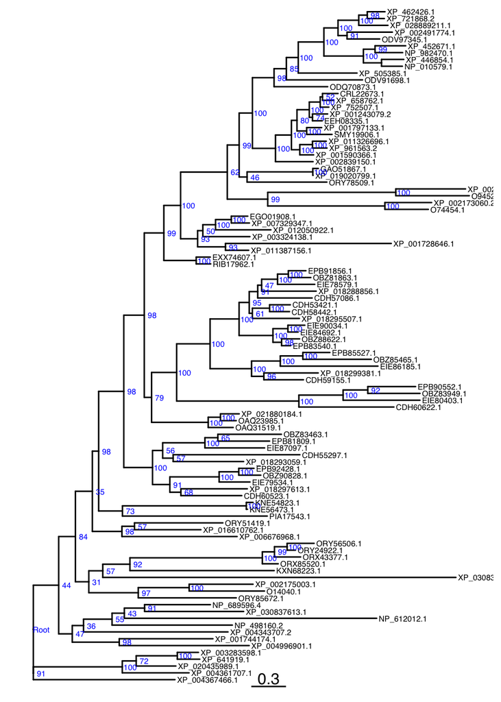

```r
ggtree(tree_IQML) +
    geom_tiplab(size=2) +
    geom_treescale(fontsize=4) +
    geom_nodelab(size=2,nudge_x=0.05,colour="blue")
```

# Load info and features

Load data frame with sequence info and features

```r
Dis3L2_features_df <-
  here::here("data", "Dis3L2_only", "Dis3L2_BLASTp_select_features.txt") %>%
  read_tsv(comment="#", col_types = c("ccccclliiiiiiiil"))%>%
  mutate(Extension=replace_na(Extension, ""),
         Clade = factor(Clade, levels = unique(Clade))
         )
```

## Integrate features with IQ-TREE data

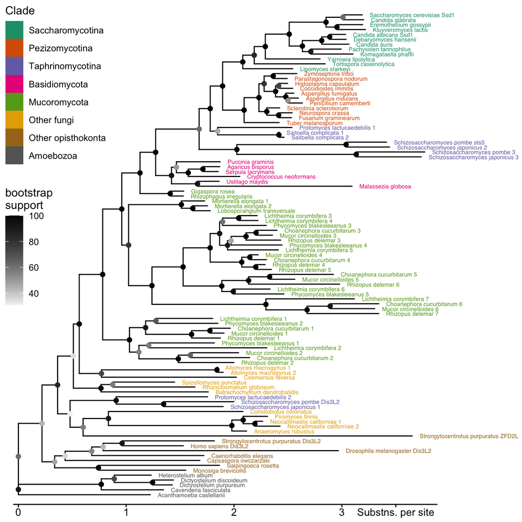

```r
ggt_taxa_IQML <-
  ggtree(tree_IQML,ladderize=FALSE) %<+%
  dplyr::rename(Dis3L2_features_df,label=ID) +
    geom_tiplab(aes(label=paste(Organism,Extension),colour=Clade),
                size=2, key_glyph="rect",offset=0.05) +
    scale_colour_brewer(type="qual",palette="Dark2",
                       guide = guide_legend(order = 1)) +
    ggnewscale::new_scale_color() +
    geom_nodepoint(aes(colour=as.numeric(label)),size=1.8) +
    scale_colour_gradient("bootstrap\nsupport",low="grey95",high="black",
                       guide = guide_colourbar(order = 2)) +
    scale_y_reverse(expand=c(0.02,0.02)) +
    scale_x_continuous(expand=c(0.01,0.01),
                       breaks=c(0:3,3.5),
                       labels=c(0:3,"Substns. per site")) +
    coord_cartesian(clip="off",) +
    theme(legend.position=c(0.1,0.7),
          plot.margin=margin(t=5,r = 82, b=5, l=10),
          axis.line.x.bottom = element_line(size=0.5,colour="black"),
          axis.ticks.x.bottom = element_line(size=0.5,colour="black"),
          axis.text.x = element_text(size=10,colour="black"))
ggt_taxa_IQML
```

## Get tips in order from tree

```r
Dis3L2_features_df_treeIQML_order <-
  ggt_taxa_IQML$data %>%
  filter(isTip) %>%
  arrange(y)
Dis3L2_features_df_treeIQML_order
```

```
##    parent node branch.length          label isTip        x  y    branch
## 1     101    1   0.180128312    NP_010579.1  TRUE 3.189922  1 3.0998574
## 2     101    2   0.192224010    XP_446854.1  TRUE 3.202017  2 3.1059053
## 3     103    3   0.238430245    NP_982470.1  TRUE 3.192348  3 3.0731325
## 4     103    4   0.264927004    XP_452671.1  TRUE 3.218844  4 3.0863809
## 5     107    5   0.147528069    XP_721868.2  TRUE 3.034311  5 2.9605470
## 6     107    6   0.152935115    XP_462426.1  TRUE 3.039718  6 2.9632505
## 7     106    7   0.252380739 XP_028889211.1  TRUE 3.065384  7 2.9391935
## 8     108    8   0.282273506     ODV97345.1  TRUE 2.994042  8 2.8529055
## 9     108    9   0.391837207 XP_002491774.1  TRUE 3.103606  9 2.9076873
## 10    109   10   0.507833526    XP_505385.1  TRUE 2.797898 10 2.5439815
## 11    110   99   0.658035368     ODV91698.1  TRUE 2.845358 11 2.5163403
## 12    111   98   0.463572395     ODQ70873.1  TRUE 2.544375 12 2.3125884
## 13    116   11   0.219194481     SMY19906.1  TRUE 2.582182 13 2.4725845
## 14    116   12   0.129455765 XP_001797133.1  TRUE 2.492443 14 2.4277152
```

[output cut: 585 more lines]

```r
Dis3L2_treeIQML_orderonly <- Dis3L2_features_df_treeIQML_order$label
```

## Plot some features in tree order

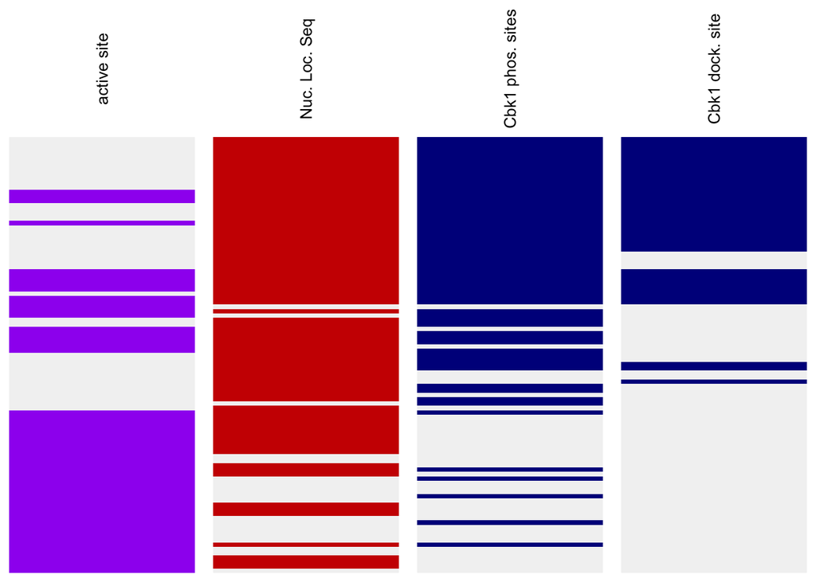

```r
p_activesite <- ggplot(data=Dis3L2_features_df_treeIQML_order,
                       aes(y=y,fill=activesite,x=1)) +
  geom_tile() +
  scale_y_reverse(expand=c(0.02,0.02)) +
  theme_void() +
  scale_fill_manual(values=c("FALSE"="grey95","TRUE"="purple")) +
  labs(title="active site") +
  theme(plot.title=element_text(size = 10,colour = "black",angle=90,vjust=0.5),
        legend.position="none")

p_NLS <- ggplot(data=Dis3L2_features_df_treeIQML_order,
                       aes(y=y,fill=NLS_Ssd1like,x=1)) +
  geom_tile() +
  scale_y_reverse(expand=c(0.02,0.02)) +
  theme_void() +
  scale_fill_manual(values=c("FALSE"="grey95","TRUE"="red3"))  +
  labs(title="Nuc. Loc. Seq") +
  theme(plot.title=element_text(size = 10,colour = "black",angle=90,vjust=0.5),
        legend.position="none")

p_Cbk1phos <- ggplot(data=Dis3L2_features_df_treeIQML_order,
                       aes(y=y,fill=cbk1cons_count>0,x=1)) +
  geom_tile() +
  scale_y_reverse(expand=c(0.02,0.02)) +
  theme_void() +
  scale_fill_manual(values=c("FALSE"="grey95","TRUE"="darkblue"))  +
  labs(title="Cbk1 phos. sites") +
  theme(plot.title=element_text(size = 10,colour = "black",angle=90,vjust=0.5),
        legend.position="none")

p_Cbk1dock <- ggplot(data=Dis3L2_features_df_treeIQML_order,
                       aes(y=y,fill=cbk1dock_count>0,x=1)) +
  geom_tile() +
  scale_y_reverse(expand=c(0.02,0.02)) +
  theme_void() +
  scale_fill_manual(values=c("FALSE"="grey95","TRUE"="darkblue"))  +
  labs(title="Cbk1 dock. site") +
  theme(plot.title=element_text(size = 10,colour = "black",angle=90,vjust=0.5),
        legend.position="none")

plot_grid(p_activesite,p_NLS, p_Cbk1phos, p_Cbk1dock,
          nrow=1,align="h")
```

## Plot the tree with the feature heatmaps

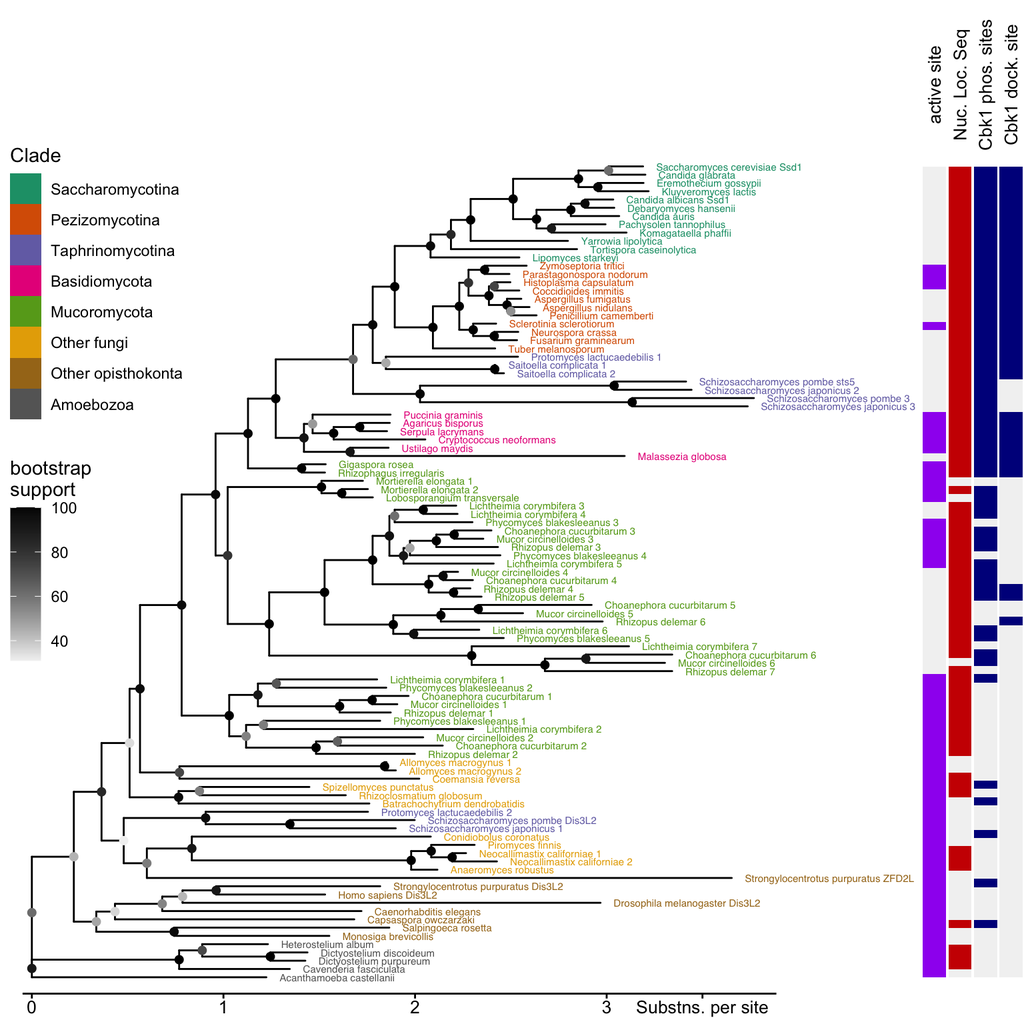

```r
plot_taxa_IQML_featureheatmaps <-
  plot_grid(ggt_taxa_IQML,p_activesite,p_NLS, p_Cbk1phos, p_Cbk1dock,
          align="h", rel_widths = c(36,1,1,1,1),nrow=1)
plot_taxa_IQML_featureheatmaps
```

```r
ggsave(filename = here::here("figure","figure2_taxa_IQML_featureheatmaps.svg"),
       plot = plot_taxa_IQML_featureheatmaps,
       width = 8, height = 8)
```

## Reorder the list of sequences by tip order

```r
Dis3L2_features_df_treeIQML_order
```

```
##    parent node branch.length          label isTip        x  y    branch
## 1     101    1   0.180128312    NP_010579.1  TRUE 3.189922  1 3.0998574
## 2     101    2   0.192224010    XP_446854.1  TRUE 3.202017  2 3.1059053
## 3     103    3   0.238430245    NP_982470.1  TRUE 3.192348  3 3.0731325
## 4     103    4   0.264927004    XP_452671.1  TRUE 3.218844  4 3.0863809
## 5     107    5   0.147528069    XP_721868.2  TRUE 3.034311  5 2.9605470
## 6     107    6   0.152935115    XP_462426.1  TRUE 3.039718  6 2.9632505
## 7     106    7   0.252380739 XP_028889211.1  TRUE 3.065384  7 2.9391935
## 8     108    8   0.282273506     ODV97345.1  TRUE 2.994042  8 2.8529055
## 9     108    9   0.391837207 XP_002491774.1  TRUE 3.103606  9 2.9076873
## 10    109   10   0.507833526    XP_505385.1  TRUE 2.797898 10 2.5439815
## 11    110   99   0.658035368     ODV91698.1  TRUE 2.845358 11 2.5163403
## 12    111   98   0.463572395     ODQ70873.1  TRUE 2.544375 12 2.3125884
## 13    116   11   0.219194481     SMY19906.1  TRUE 2.582182 13 2.4725845
## 14    116   12   0.129455765 XP_001797133.1  TRUE 2.492443 14 2.4277152
```

[output cut: 585 more lines]

```r
fasta_mafftlocal_trimal_deltaNterm1to337 <-
  here::here("data","Dis3L2_only",
  "Dis3L2_BLASTp_select_fullseqs_mafftlocal_trimal_deltaNterm1to337.fasta") %>%
  Biostrings::readAAStringSet() %>%
  .[Dis3L2_features_df_treeIQML_order$label]
fasta_mafftlocal_trimal_deltaNterm1to337
```

```
## AAStringSet object of length 99:
##      width seq                                              names
##  [1]  1071 RKSLFAPYLPQANIPELIQEGRL...MKRV------------------ NP_010579.1
##  [2]  1071 RKSLFAPYLPQANIPQLIQEGRL...MKVEPKH--------------- XP_446854.1
##  [3]  1071 RKSLFAPYLPQANIPQLIEEGRL...TSRD------------------ NP_982470.1
##  [4]  1071 RKSLFAPYLPQANIPQLIEEGKL...MRS------------------- XP_452671.1
##  [5]  1071 RKTLFAPYLPQSSLPELINEGRL...AEEQ------------------ XP_721868.2
##  ...   ... ...
## [95]  1071 RKARFPAHVTIEEVEKGLSTSKY...YVGN------------------ XP_020435989.1
## [96]  1071 TRLFYKQYVEKEDLEKGLAEGKY...TI-------------------- XP_641919.1
## [97]  1071 KRQFYTPYITKEQLDQGLAEGKY...L--------------------- XP_003283598.1
## [98]  1071 RRNRFDIHLSREDVQSGLDKGDL...HINIDSIPVVKNK--------- XP_004361707.1
## [99]  1071 RRSRFKEHLSSEEVEQGLKDGTL...GAAVPDNYYDAPVNEARDDEAM XP_004367466.1
```

```r
# Biostrings::writeXStringSet(
#   fasta_mafftlocal_trimal_deltaNterm1to337,
#     here::here("data","Dis3L2_only",
#   "Dis3L2_BLASTp_select_fullseqs_mafftlocal_trimal_deltaNterm1to337_treeIQMLorder.fasta")
#   )
```

## Pairwise sequence identity

For domains:

### Calculate distance matrix and percent identity matrix in tidy format

```r
dist_deltaNterm1to337 <-
  fasta_mafftlocal_trimal_deltaNterm1to337 %>%
  Biostrings::stringDist(method="hamming") %>%
  broom::tidy() %>%
  dplyr::transmute(ID1=factor(item1,levels=Dis3L2_treeIQML_orderonly),
                   ID1rev=factor(item1,levels=rev(Dis3L2_treeIQML_orderonly)),
                   ID2=factor(item2,levels=Dis3L2_treeIQML_orderonly),
                   ID2rev=factor(item2,levels=rev(Dis3L2_treeIQML_orderonly)),
                   seqwidth=1071,
                percid = (seqwidth-distance)/seqwidth * 100)

dist_CSD12 <-
  fasta_mafftlocal_trimal_deltaNterm1to337 %>%
  Biostrings::subseq(start=1,end=324) %>%
  Biostrings::stringDist(method="hamming") %>%
  broom::tidy() %>%
  dplyr::transmute(ID1=factor(item1,levels=Dis3L2_treeIQML_orderonly),
                   ID1rev=factor(item1,levels=rev(Dis3L2_treeIQML_orderonly)),
                   ID2=factor(item2,levels=Dis3L2_treeIQML_orderonly),
                   ID2rev=factor(item2,levels=rev(Dis3L2_treeIQML_orderonly)),
                   seqwidth=324,
                percid = (seqwidth-distance)/seqwidth * 100)

dist_RNII <-
  fasta_mafftlocal_trimal_deltaNterm1to337 %>%
  Biostrings::subseq(start=356,end=712) %>%
  Biostrings::stringDist(method="hamming") %>%
  broom::tidy() %>%
  dplyr::transmute(ID1=factor(item1,levels=Dis3L2_treeIQML_orderonly),
                   ID1rev=factor(item1,levels=rev(Dis3L2_treeIQML_orderonly)),
                   ID2=factor(item2,levels=Dis3L2_treeIQML_orderonly),
                   ID2rev=factor(item2,levels=rev(Dis3L2_treeIQML_orderonly)),
                   seqwidth=357,
                percid = (seqwidth-distance)/seqwidth * 100)
```

### Spot-check percent identity of CSDs

```r
Dis3L2_nameext_few <-
  Dis3L2_features_df %>%
  filter(
    Organism %in% c("Saccharomyces cerevisiae",
                    "Cryptococcus neoformans",
                    "Schizosaccharomyces pombe",
                    "Homo sapiens")
  ) %>%
  transmute(ID,
            Shortname = str_replace(Organism,"([A-Z])[a-z]+", "\\1.") %>%
              paste(Extension)
            )

dist_CSD12 %>%
  select(ID1,ID2,percid) %>%
  inner_join( Dis3L2_nameext_few %>% rename(ID1 = ID, Shortname1=Shortname) ) %>%
  inner_join( Dis3L2_nameext_few %>% rename(ID2 = ID, Shortname2=Shortname) )
```

```
## # A tibble: 15 x 5
##    ID1            ID2            percid Shortname1           Shortname2
##    <chr>          <chr>           <dbl> <chr>                <chr>
##  1 NP_010579.1    O74454.1         54.9 "S. cerevisiae Ssd1" "S. pombe sts5"
##  2 NP_010579.1    O94525.1         48.8 "S. cerevisiae Ssd1" "S. pombe 3"
##  3 NP_010579.1    XP_012050922.1   57.1 "S. cerevisiae Ssd1" "C. neoformans "
##  4 NP_010579.1    O14040.1         30.9 "S. cerevisiae Ssd1" "S. pombe Dis3L2"
##  5 NP_010579.1    NP_689596.4      29.3 "S. cerevisiae Ssd1" "H. sapiens Dis3L2"
##  6 O74454.1       O94525.1         50.3 "S. pombe sts5"      "S. pombe 3"
##  7 O74454.1       XP_012050922.1   59.3 "S. pombe sts5"      "C. neoformans "
##  8 O74454.1       O14040.1         33.0 "S. pombe sts5"      "S. pombe Dis3L2"
##  9 O74454.1       NP_689596.4      27.8 "S. pombe sts5"      "H. sapiens Dis3L2"
## 10 O94525.1       XP_012050922.1   51.5 "S. pombe 3"         "C. neoformans "
## 11 O94525.1       O14040.1         29.0 "S. pombe 3"         "S. pombe Dis3L2"
## 12 O94525.1       NP_689596.4      25.6 "S. pombe 3"         "H. sapiens Dis3L2"
## 13 XP_012050922.1 O14040.1         37.0 "C. neoformans "     "S. pombe Dis3L2"
## 14 XP_012050922.1 NP_689596.4      31.8 "C. neoformans "     "H. sapiens Dis3L2"
## 15 O14040.1       NP_689596.4      33.3 "S. pombe Dis3L2"    "H. sapiens Dis3L2"
```

### Spot-check percent identity of RNII

```r
dist_RNII %>%
  select(ID1,ID2,percid) %>%
  inner_join( Dis3L2_nameext_few %>% rename(ID1 = ID, Shortname1=Shortname) ) %>%
  inner_join( Dis3L2_nameext_few %>% rename(ID2 = ID, Shortname2=Shortname) )
```

```
## # A tibble: 15 x 5
##    ID1            ID2            percid Shortname1           Shortname2
##    <chr>          <chr>           <dbl> <chr>                <chr>
##  1 NP_010579.1    O74454.1         33.1 "S. cerevisiae Ssd1" "S. pombe sts5"
##  2 NP_010579.1    O94525.1         33.3 "S. cerevisiae Ssd1" "S. pombe 3"
##  3 NP_010579.1    XP_012050922.1   31.1 "S. cerevisiae Ssd1" "C. neoformans "
##  4 NP_010579.1    O14040.1         27.2 "S. cerevisiae Ssd1" "S. pombe Dis3L2"
##  5 NP_010579.1    NP_689596.4      28.6 "S. cerevisiae Ssd1" "H. sapiens Dis3L2"
##  6 O74454.1       O94525.1         33.9 "S. pombe sts5"      "S. pombe 3"
##  7 O74454.1       XP_012050922.1   27.2 "S. pombe sts5"      "C. neoformans "
##  8 O74454.1       O14040.1         27.5 "S. pombe sts5"      "S. pombe Dis3L2"
##  9 O74454.1       NP_689596.4      28.0 "S. pombe sts5"      "H. sapiens Dis3L2"
## 10 O94525.1       XP_012050922.1   27.5 "S. pombe 3"         "C. neoformans "
## 11 O94525.1       O14040.1         25.8 "S. pombe 3"         "S. pombe Dis3L2"
## 12 O94525.1       NP_689596.4      27.7 "S. pombe 3"         "H. sapiens Dis3L2"
## 13 XP_012050922.1 O14040.1         42.0 "C. neoformans "     "S. pombe Dis3L2"
## 14 XP_012050922.1 NP_689596.4      45.4 "C. neoformans "     "H. sapiens Dis3L2"
## 15 O14040.1       NP_689596.4      46.2 "S. pombe Dis3L2"    "H. sapiens Dis3L2"
```

### Plot percent identity matrices as heatmaps

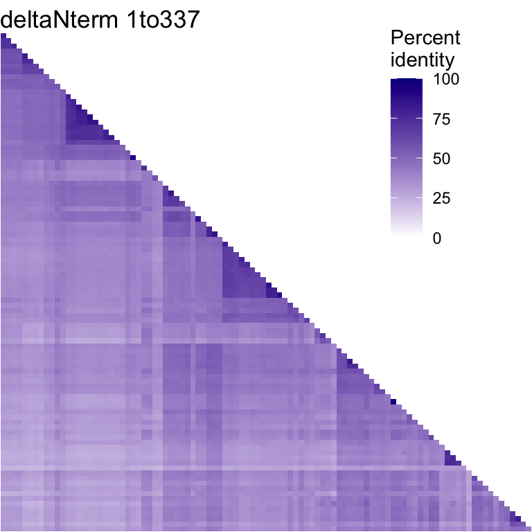

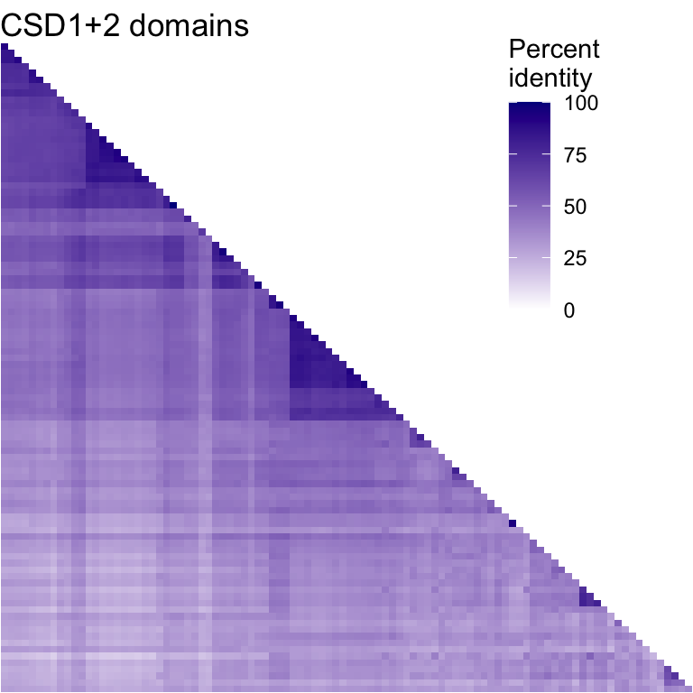

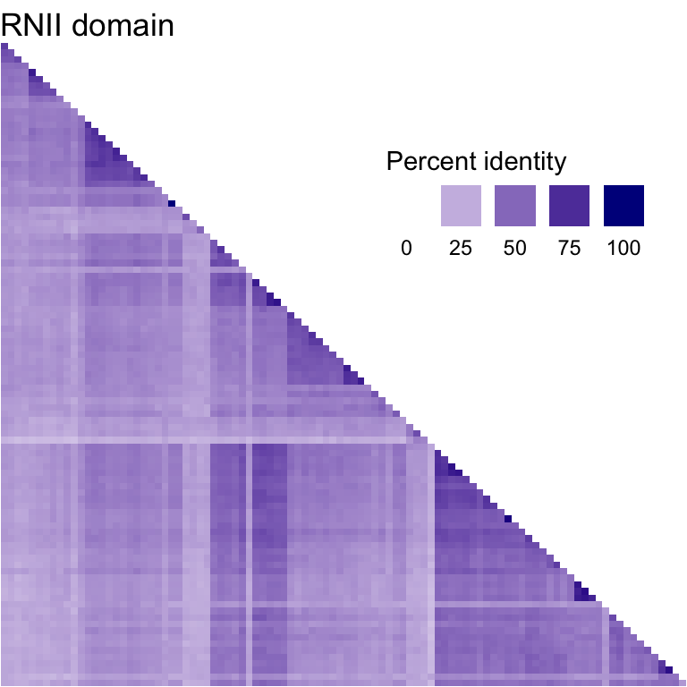

### Plot percent identity of domains including cladogram information

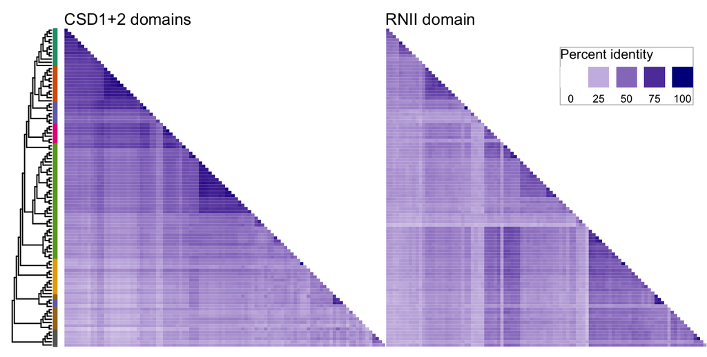

# Session Info